# Exercises project

Thomas Kirschstein

# Data description

The data set “biathlon_results_women.csv” contains results of all womens’ biathlon races of the IBU World Cup, the World Championships, and at the Olympic Games from season 2008/09 till 2017/18. The raw data is extracted from [IBU results homepage](https://biathlonresults.com/) where also a description of the variables is provided.

| name | description |
| --- | --- |
| date | race date in d.m.year format |
| season | season id |
| competition | Type of competition (I…Individual, S…Sprint, M…Mass start, P…Pursuit) |
| type | Type of race (W…world Cup, O…Olympic, C…World Championship) |
| name | Name of athlete |
| nation | nation of athlete |
| rank | final rank (total time) |
| course.rank | final rank (course time) |
| tot.time | total time at finish (in seconds) |
| course.time | course time at finish (in seconds) |
| location | race location |
| elevation | elevation of location (in m) |
| height.diff | height difference of course profile (in m) |
| max.climb | maximum climb in course profile (in m) |
| total.climb | total climb over course (in m) |
| birthday | birthday of athlete |
| snow.conditions | snow conditions (check IBU website, [wiki](https://en.wikipedia.org/wiki/Classifications_of_snow), [blog](http://blog.tahoemountainsports.com/tahoe-cross-country-skiing-well-its-about-time/)) |
| snow.temperature | snow temperature (in $^\circ$C) |
| air.temperature | air temperature (in $^\circ$C) |
| weather.conditions | weather conditions (self-explaining) |
| fails.total | total number of missed targets in shooting |
| speed | skiing speed, i.e. course length/course time (in m/s) |
| age | age of athlete at race time (in years) |
| home | whether it was a home race |

# Task

Compose a report with a descriptive analysis of the data. Investigate which variables affect the skiing speed of the athletes. Use basic statistics as well as appropriate plots to illustrate the effects of environmental conditions or course profiles on skiing speed.

# Read data

At first read the data set into the workspace either via the console or the “import dataset” dialog in environment menu (right upper pane).

```r
biathlon_results_women <- read.csv("~/Thomas/Owncloud/Data_Science_PL/R-Skripte/DatsciWiR_exercise/exercise_case_study/biathlon_results_women.csv")
```

The data should look like this:

```r
library(DT)
datatable(head(biathlon_results_women, 50))
```

|  | date | season | competition | type | name | nation | rank | course.rank | tot.time | course.time | location | elevation | height.diff | max.climb | total.climb | birthday | snow.conditions | snow.temperature | air.temperature | weather.conditions | fails.total | speed | age | home |
| --- | --- | --- | --- | --- | --- | --- | --- | --- | --- | --- | --- | --- | --- | --- | --- | --- | --- | --- | --- | --- | --- | --- | --- | --- |
| 1 | 10-12-1 | 10-11 | I | W | OLOFSSON-ZIDEK Anna Carin | SWE | 1 | 14 | 2726.1 | 2443.6 | Östersund | 364 | 48 | 48 | 129 | 1.4.1973 | Hard | -12.5 | -10.2 | Sky Clear | 0 | 6.13848420363398 | 37.6931506849315 | Aboard |
| 2 | 10-12-1 | 10-11 | I | W | BRUNET Marie Laure | FRA | 2 | 2 | 2735 | 2371.2 | Östersund | 364 | 48 | 48 | 129 | 20.11.1988 | Hard | -12.5 | -10.2 | Sky Clear | 2 | 6.32591093117409 | 22.0438356164384 | Aboard |
| 3 | 10-12-1 | 10-11 | I | W | EKHOLM Helena | SWE | 3 | 4 | 2768.8 | 2384.7 | Östersund | 364 | 48 | 48 | 129 | 6.9.1984 | Hard | -12.5 | -10.2 | Sky Clear | 2 | 6.29009938357026 | 26.2521689497717 | Aboard |
| 4 | 10-12-1 | 10-11 | I | W | SEMERENKO Valj | UKR | 4 | 7 | 2785.2 | 2406.7 | Östersund | 364 | 48 | 48 | 129 | 18.1.1986 | Hard | -12.5 | -10.2 | Sky Clear | 2 | 6.2326006565006 | 24.8849315068493 | Aboard |
| 5 | 10-12-1 | 10-11 | I | W | ROMANOVA Iana | RUS | 5 | 42 | 2795.9 | 2551.9 | Östersund | 364 | 48 | 48 | 129 | 11.5.1983 | Hard | -12.5 | -10.2 | Sky Clear | 0 | 5.87797327481484 | 27.578196347032 | Aboard |
| 6 | 10-12-1 | 10-11 | I | W | ZAITSEVA Olga | RUS | 6 | 8 | 2798.3 | 2407.5 | Östersund | 364 | 48 | 48 | 129 | 16.5.1978 | Hard | -12.5 | -10.2 | Sky Clear | 2 | 6.23052959501558 | 32.5671232876712 | Aboard |
| 7 | 10-12-1 | 10-11 | I | W | GREGORIN Teja | SLO | 7 | 3 | 2834.7 | 2372.7 | Östersund | 364 | 48 | 48 | 129 | 29.6.1980 | Hard | -12.5 | -10.2 | Sky Clear | 3 | 6.32191174611202 | 30.4439497716895 | Aboard |
| 8 | 10-12-1 | 10-11 | I | W | SLEPTSOVA Svetlana | RUS | 8 | 11 | 2843.9 | 2423.9 | Östersund | 364 | 48 | 48 | 129 | 31.7.1986 | Hard | -12.5 | -10.2 | Sky Clear | 3 | 6.18837410784273 | 24.3535388127854 | Aboard |
| 9 | 10-12-1 | 10-11 | I | W | HENKEL Andrea | GER | 9 | 9 | 2855.2 | 2407.6 | Östersund | 364 | 48 | 48 | 129 | 10.12.1977 | Hard | -12.5 | -10.2 | Sky Clear | 3 | 6.2302708091045 | 32.9972602739726 | Aboard |
| 10 | 10-12-1 | 10-11 | I | W | FLATLAND Ann Kristin Aafedt | NOR | 10 | 10 | 2869.3 | 2422.6 | Östersund | 364 | 48 | 48 | 129 | 6.11.1982 | Hard | -12.5 | -10.2 | Sky Clear | 3 | 6.19169487327664 | 28.0876712328767 | Aboard |

[output cut: 40 more lines]

# Analysis

## Preparation

Usually there is some code you need to execute before your analysis with the starts. This workspace setup often comprises of loading the raw data itself, starting some packages, or sourcing some previsoulsy written functions. This part of the code is typically not that interesting for a reader, therefore it is often advisable to put it into a separate code chunk which is not displayed in the report compiled later on:

## Get an overview & make hypotheses

Typically you start a data analysis project with getting an overview on the data. A part of this task has been accomplished in the data description section above. Important is that you try to present information relevant for the reader w.r.t. the particular research question to be discussed. Often this structure of an analysis is organized via hypotheses which are introduced at the beginning of the report.

One hypothesis could be that the competition types affect skiing speed (i.e., speed in mass start and sprint differ as for Olympic and world cup races). In order to check this hypothesis, the first question to be answered is, how many observations are present in the different combinations of competition types. The total number of of observations can be computed like this:

```r
with(biathlon_results_women, table(competition , type))
```

```
##            type
## competition    C    O    W
##           I  716  251 2098
##           M  208   58 1182
##           P  329  171 3683
##           S  739  259 8026
```

These numbers seem reassuring. However, there are also other factors affecting such as the snow conditions. Thus, to make reliable statements on the effects competition types, the remaining potentially effecting variables should be distributed in similarly in the races considered in combination of competition types. Without controlling these externalities precisely, we can look at the number of *races* in each category instead of the number of observations (as all athletes in a race face the same track and weather as well as snow condtions).

```r
tmp <- aggregate(date ~ competition + type, biathlon_results_women , function(x) length(unique(x) ))
tmp2 <- matrix(tmp$date, ncol = 3, nrow = 4)
# add sums
tmp2 <- cbind(tmp2, rowSums(tmp2))
tmp2 <- rbind(tmp2, colSums(tmp2))
# add row and column titles
colnames(tmp2) <- c(unique(tmp$type),"sum")
rownames(tmp2) <- c(unique(tmp$competition),"sum")

kable(tmp2, "pandoc")
```

|  | C | O | W | sum |
| --- | --- | --- | --- | --- |
| I | 7 | 3 | 22 | 32 |
| M | 7 | 2 | 40 | 49 |
| P | 6 | 3 | 67 | 76 |
| S | 7 | 3 | 87 | 97 |
| sum | 27 | 11 | 216 | 254 |

```r
# ANOVA with all data - just main effects
res.aov.main <- aov(speed ~ type + competition, data = biathlon_results_women)
# F tests
summary(res.aov.main)
```

```
##                Df Sum Sq Mean Sq F value Pr(>F)
## type            2     42   21.09   109.6 <2e-16 ***
## competition     3    145   48.46   251.8 <2e-16 ***
## Residuals   17714   3408    0.19
## ---
## Signif. codes:  0 '***' 0.001 '**' 0.01 '*' 0.05 '.' 0.1 ' ' 1
```

```r
# estimated coefficients
res.aov.main$coefficients
```

```
##  (Intercept)        typeO        typeW competitionM competitionP competitionS
##    5.9849753    0.1499749   -0.1019826    0.3382064    0.2244410    0.1282635
```

```r
# test pairwise differences
TukeyHSD(res.aov.main)
```

```
##   Tukey multiple comparisons of means
##     95% family-wise confidence level
##
## Fit: aov(formula = speed ~ type + competition, data = biathlon_results_women)
##
## $type
##            diff         lwr        upr p adj
## O-C  0.15343880  0.10915426  0.1977233     0
## W-C -0.07145154 -0.09597088 -0.0469322     0
## W-O -0.22489034 -0.26363272 -0.1861480     0
##
## $competition
##            diff         lwr         upr p adj
## M-I  0.33432743  0.29838866  0.37026621     0
## P-I  0.21859999  0.19180337  0.24539661     0
## S-I  0.12219184  0.09862993  0.14575375     0
## P-M -0.11572744 -0.15009073 -0.08136416     0
## S-M -0.21213560 -0.24404077 -0.18023042     0
## S-P -0.09640816 -0.11748904 -0.07532728     0
```

```r
# Alternative: General linear model
res.lm <- lm(speed ~ type + competition, data = biathlon_results_women)
summary(res.lm)
```

```
##
## Call:
## lm(formula = speed ~ type + competition, data = biathlon_results_women)
##
## Residuals:
##      Min       1Q   Median       3Q      Max
## -1.65610 -0.29475  0.02259  0.30666  1.29175
##
## Coefficients:
##               Estimate Std. Error t value Pr(>|t|)
## (Intercept)   5.984975   0.011371 526.349  < 2e-16 ***
## typeO         0.149975   0.018902   7.934 2.24e-15 ***
## typeW        -0.101983   0.010658  -9.568  < 2e-16 ***
## competitionM  0.338206   0.014042  24.085  < 2e-16 ***
## competitionP  0.224441   0.010591  21.191  < 2e-16 ***
## competitionS  0.128264   0.009368  13.691  < 2e-16 ***
## ---
## Signif. codes:  0 '***' 0.001 '**' 0.01 '*' 0.05 '.' 0.1 ' ' 1
##
## Residual standard error: 0.4387 on 17714 degrees of freedom
## Multiple R-squared:  0.05215,    Adjusted R-squared:  0.05189
## F-statistic: 194.9 on 5 and 17714 DF,  p-value: < 2.2e-16
```

Based on the ANOVA results also pairwise comparisons between the groups’ means can be made (carefully due to the multiple testing problem). Aside the `aov()` function, applying `lm()` yields the same result (as long as the variables are properly defined). *Homework*: Compare goodness-of-fit and coefficients of both approaches.

To display the results of an ANOVA, usually boxplots/violine plots and interaction plots are used. Boxplots give an overall impression of the data and show the distribution of the dependent variable in the different groups.

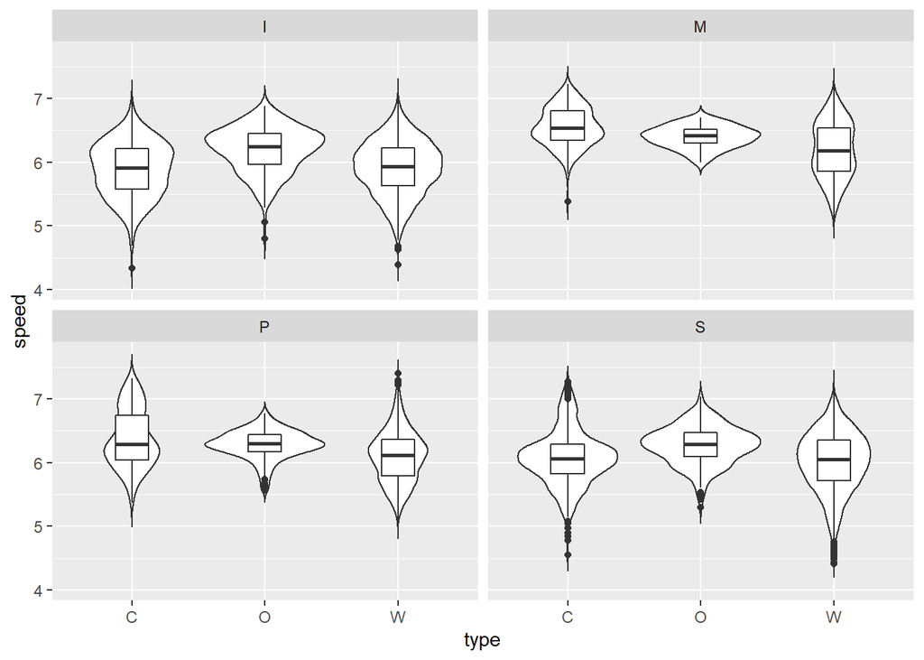

```r
ggplot(data = biathlon_results_women, aes(x = type, y = speed)) +
  geom_violin(trim = F) +
  geom_boxplot(width = .25) +
  facet_wrap(~competition)
```

Due to the complete distributional information, it is not obvious whether the dependent variable differs in the groups on average when looking at boxplots/violine plots only. Interaction plots therefore condense location information by displaying only the means or other measures of location sometimes also accompanied by some measure of distribution.

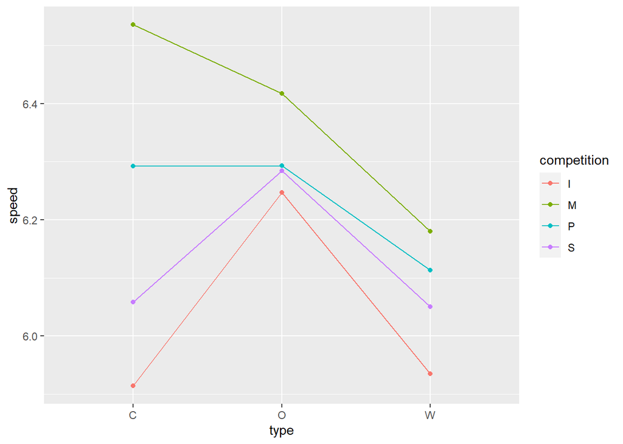

```r
ggplot(data = biathlon_results_women, aes(x = type, color = competition, group = competition, y = speed)) +
  stat_summary(fun = median, geom = "point") +
  stat_summary(fun = median, geom = "line")
```

## Dive into details

Once you obtained an overview, its time to look into the details. Often reality is complex and many aspects that have not been considered so far may invalidate the results of simple 1st-glimpse impressions. To circumvent this problem, one should look only at subsets of the data where the variable of interest varies, but the remaining variables are as fixed as possible.

For example, the high speeds in the Olympic Sprint and Individual races might be caused by favorable weather conditions or easy course profiles. To check whether weather conditions have an impact on skiing speed, one can look at the races at a given location and given type over time. This way, competition type and course effects are fixed. A location which is regularly visited during a season is Oberhof, Germany. Additionally, wheather is notoriously instable there.

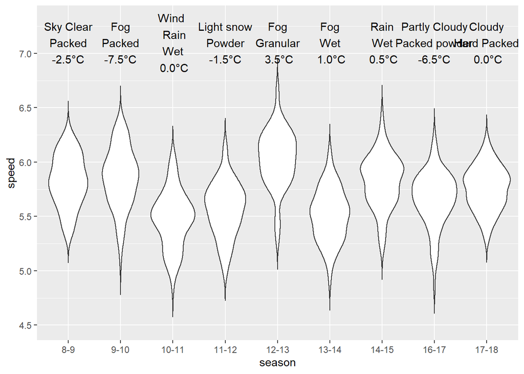

```r
# Sprint results in Oberhof
tmp <- subset(biathlon_results_women, location == "Oberhof" & competition == "S")
# conVert season into factor
tmp$season <- as.factor(tmp$season)
# reorder factor levels chronologically
tmp$season <- factor(tmp$season , levels(tmp$season)[c(8:9, 1:7)])
# prepare environmental conditions
tmp.anno <- cbind(
  aggregate(weather.conditions ~ season,  tmp, unique),
  aggregate(snow.conditions ~ season,  tmp, unique)[,2],
  aggregate(snow.temperature ~ season,  tmp, unique)[,2])
# build annotation strings
tmp.anno <- data.frame(season = tmp.anno[,1], anno = paste(apply(tmp.anno[,-1], 1, function(x) paste(x, collapse="&")),"°C", sep=""))
# function for formatting annotations
addline_format <- function(x,...){
  gsub('&','\n',x) #\\s
}

ggplot(tmp, aes(y = speed, x=season)) +
  geom_violin(trim = F) +
  geom_text(data = tmp.anno,
            aes(x = season, y = 7.1, label = addline_format(anno))) +
  ylim(4.5,7.3)
```

The parallel violine plots indicate that environmental conditions may have a noteworthy influence on speed. Particularly, high snow temperature (>0°C) and wet/soft snow seem to be problematic (although, not always, see season 12-13).

## Data manipulation

Preliminary analyses often reveal that some data or variables have to be manipulated to decide for or against the research hypothesis. Data manipulation comprises of e.g. omitting observations (e.g., due to missing data or measurement errors), data imputation (in case of missing data), and variable transformation

For example, snow and weather conditions are often hard to distinguish. A strategy to remedy noisy level definitions is to construct simplified variables.

```r
# extract snow conditions in vector & convert it to factor
snow.cond.simplest <- as.factor(biathlon_results_women$snow.conditions)
# all levels containing wet or soft are relabeled as "wet"
levels(snow.cond.simplest)[grepl("wet|Wet|soft|Soft", levels(snow.cond.simplest) )] <- "wet"
# all levels containing hard, packed, or compact are relabeled as "hard"
levels(snow.cond.simplest)[grepl("hard|Hard|Compact|Packed|packed", levels(snow.cond.simplest) )] <- "hard"
# all levels containing powder, or granular are relabeled as "hard"
levels(snow.cond.simplest)[grepl("Powder|powder|granular|Granular", levels(snow.cond.simplest) )] <- "granular"

# extract weather conditions in vector & convert it to factor
weather.cond.simplest <- as.factor(biathlon_results_women$weather.conditions)
# distinguish only factors "dry" and "precipitation"
levels(weather.cond.simplest)[grepl("clear|Clear|sunny|Sunny|cloudy|Cloudy|Fog|fog", levels(weather.cond.simplest) )] <- "dry"
levels(weather.cond.simplest)[grepl("snow|Snow|rain|Rain", levels(weather.cond.simplest) )] <- "precip"
# add to dataset
biathlon_results_women <- add_column(snow.cond.simplest = snow.cond.simplest, weather.cond.simplest = weather.cond.simplest, biathlon_results_women)
```

## Data analysis

Finally, some analysis technique(s) should be applied for answering the research question/hypothesis.

For example, a linear model might be appropriate to study the effects of the aforementioned variables.

```r
# extract snow conditions in vector & convert it to factor
lm.mod <- lm(speed ~ competition + type + snow.cond.simplest + weather.cond.simplest + age + I(age^2) + snow.temperature + I(snow.temperature^2) + air.temperature + elevation , data = biathlon_results_women)
summary(lm.mod)
```

```
##
## Call:
## lm(formula = speed ~ competition + type + snow.cond.simplest +
##     weather.cond.simplest + age + I(age^2) + snow.temperature +
##     I(snow.temperature^2) + air.temperature + elevation, data = biathlon_results_women)
##
## Residuals:
##      Min       1Q   Median       3Q      Max
## -1.61245 -0.27207  0.01304  0.27174  1.42832
##
## Coefficients:
##                               Estimate Std. Error t value Pr(>|t|)
## (Intercept)                  4.281e+00  7.999e-02  53.518  < 2e-16 ***
## competitionM                 3.427e-01  1.287e-02  26.621  < 2e-16 ***
## competitionP                 2.595e-01  9.753e-03  26.610  < 2e-16 ***
## competitionS                 1.809e-01  8.673e-03  20.859  < 2e-16 ***
## typeO                        1.103e-01  1.776e-02   6.208 5.47e-10 ***
## typeW                       -9.552e-02  1.003e-02  -9.521  < 2e-16 ***
## snow.cond.simplestgranular  -2.369e-01  9.443e-03 -25.091  < 2e-16 ***
## snow.cond.simplestwet       -2.245e-01  1.184e-02 -18.957  < 2e-16 ***
## weather.cond.simplestprecip -1.981e-01  7.431e-03 -26.652  < 2e-16 ***
## age                          1.189e-01  5.670e-03  20.978  < 2e-16 ***
## I(age^2)                    -1.848e-03  9.979e-05 -18.515  < 2e-16 ***
## snow.temperature            -1.961e-02  2.455e-03  -7.986 1.47e-15 ***
## I(snow.temperature^2)       -9.946e-04  1.815e-04  -5.481 4.30e-08 ***
## air.temperature              2.347e-02  8.275e-04  28.366  < 2e-16 ***
## elevation                   -7.673e-05  6.794e-06 -11.293  < 2e-16 ***
## ---
## Signif. codes:  0 '***' 0.001 '**' 0.01 '*' 0.05 '.' 0.1 ' ' 1
##
## Residual standard error: 0.3965 on 17704 degrees of freedom
##   (1 observation deleted due to missingness)
## Multiple R-squared:  0.2261, Adjusted R-squared:  0.2255
## F-statistic: 369.4 on 14 and 17704 DF,  p-value: < 2.2e-16
```

Its always advisable to check the obtained results for plausibility. In our example particularly the signs of the variables should be checked. Beyond that you may check how the functional relationships of the some variables can be visualized.